# Part II - (Loan Data From Prosper)

## by (CHIMA CALEB C)

## Investigation Overview

In this investigation, I wanted to look at the characteristics of the data to answer the following questions

- What factors affect a loan’s outcome status?
- What affects the borrower’s APR or interest rate?
- Are there differences between loans depending on how large the original loan amount was?

## Dataset Overview

This data set contains 113,937 loans with 81 variables on each loan, including loan amount, borrower rate (or interest rate), current loan status, borrower income, and many others.

`NB` This data (dictionary) explains the variables in the data set. the Focus of this analysis is basically on about 15 of the the features.

## The dataset appears unclean, so i need to clean and make it ready for analysis

- convert laonOriginationDate to datetime
- clean off date from loanoriginalquarter
- Convert ListingCategory (numeric) to a corresponding alphabetical values since its use to represent state
- Fill up the null values with zero (0)

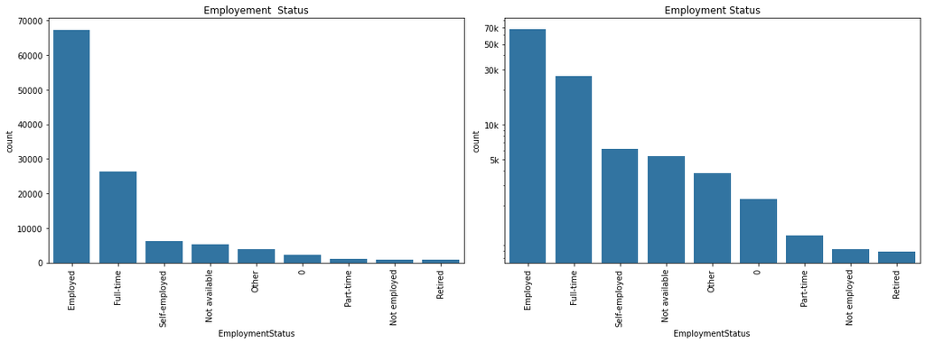

This shows that the borrowers which are employed tends to be of higher proportion than others

NB: the Zero(0) plotted is as a rsult of the null values i used to fill up the missing space instead of dropping them off to avoid interfaring with someother features

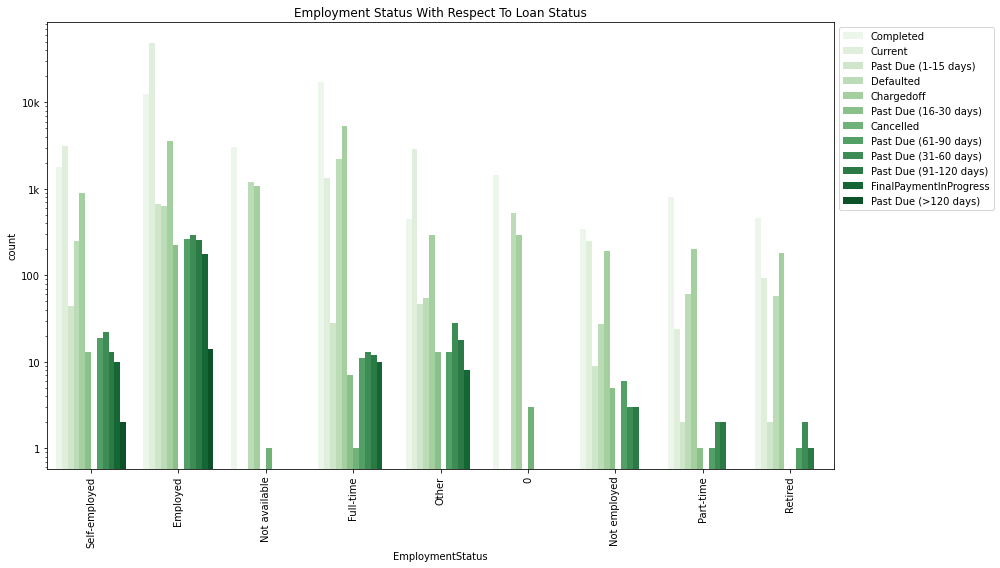